# Who Held the Seat, and Who Won the Election

A roster is not a return, and the gap between them is 2,344 people

Democracy’s Data

Last updated September 13, 2026 at 10:53a EDT

Every brief in this cluster runs on a list of people rather than a list of votes. `midterm-loss` counts the seats each party held. `retirements` and `careers` follow members in and out of office. `primary-defeats` asks which incumbents were denied renomination. None of them opens a returns file first. What they open is a **roster**: the official record of who was a member of Congress, and when.

Congress keeps that record about itself, for its own use. A chamber has to know who its members are before it can do anything else: who may vote on the floor, who draws a salary, who sits on which committee, whose seniority outranks whose. The *Biographical Directory of the United States Congress*, maintained by the House and Senate, lists every person who has ever served. It is an institution’s memory of itself, not a dataset, and every research use of it is a borrowing.

A roster and a file of election returns look interchangeable, and they are not. The returns chapter built this section’s opening cluster on a single limit: a **return** — the official tally of who ran for a seat and how many votes each got — is complete, official, and permanently silent about who voted. A roster has the mirror-image limit — it is silent about votes. And the two records do not even agree on how many people have held office. The gap between them is 2,344 people, and this chapter measures it.

## Where the data comes from, and what it is for

The rosters this cluster reads are official records of three institutions, reached mostly through one academic compilation of them. Each record exists because the institution needed it to run.

**Who is in it, and how they got there.** Everyone who was ever seated in Congress, and nobody who merely ran. One row of the membership roster is one person serving in one Congress: a name, a state and district, a party, and the span of the service. People enter the roster by being seated: after a general election, a special election, or the resolution of a contested race. They leave it by dying, resigning, losing, or walking away.

**Who it was made for.** The institution’s own operation. The Clerk of the House must know who may vote on the floor before any bill can pass. The *Biographical Directory* is the chambers’ record of their own history, and the Office of the Historian’s party-division tables exist so the House can state how many seats each party held. None of it was designed to measure turnover, careers, or competition, which are the questions this cluster asks of it.

**What it costs to get.** Nothing. Voteview, an academic project, publishes the whole membership series as one machine-readable file, compiled from the official records, with a consistent identifier for each member. The Historian’s tables and the Federal Election Commission’s returns compendium are free web pages. Nothing in this chapter is read straight from those files: every figure below comes from tables four of this cluster’s briefs already built from them.

**What has already been done to it.** Compilation and classification. Voteview merged two centuries of official rosters and gave each person one identifier, so a member who leaves and comes back is still one person. The exit classifications used below were built by matching the roster against candidate filings. A member who appears in the next election’s filings ran again. One who does not is classified by what the record shows: retired, ran for the Senate, died in office.

## Three records, and what a row is

| Roster | Published by | One row is | Answers |
| --- | --- | --- | --- |
| Membership roster | Voteview (academic, from official sources) | One member in one Congress | Who was seated, and when |
| Party divisions | Office of the Historian, U.S. House | One Congress | How many seats each party held |
| Candidate returns | Federal Election Commission | One candidate in one election | Who ran, and how many votes they got |

The three records arrive in three shapes. The *Biographical Directory* is a website, one page per member, written for people looking up one person at a time. The Historian’s party divisions are a single table on one page, extended once per Congress. Voteview’s membership file is the shape research needs: one CSV, one row per member per Congress, updated as each new Congress is sworn in. The briefs in this cluster read the third, because a page per person is a fine memory and a terrible dataset.

The last column of this table is the one to hold on to. A roster will tell you exactly who sat in the 47th Congress and for how long, and it does not contain a single ballot. The party-divisions series that `midterm-loss` runs on is the clean case: 0 of its columns carry a vote total. It counts seats.

That is a fair trade as long as seats and elections correspond. Mostly they do. The rest of this chapter is about the two places they do not, and both places are exactly where this cluster’s briefs live.

## More people than there are seats

Across 118 Congresses there have been 38,088 seat-terms to fill — one seat in one Congress is one seat-term. Count the people instead, and the number comes out larger.

| Congress | Year | Members | Seats | Excess | Deaths in office |
| --- | --- | --- | --- | --- | --- |
| 14 | 1815 | 199 | 140 | 59 | 5 |
| 16 | 1819 | 201 | 143 | 58 | 3 |
| 13 | 1813 | 196 | 141 | 55 | 2 |
| 23 | 1833 | 258 | 204 | 54 | 5 |
| 73 | 1933 | 447 | 393 | 54 | 13 |
| 15 | 1817 | 195 | 142 | 53 | 2 |
| 27 | 1841 | 259 | 207 | 52 | 10 |
| 17 | 1821 | 201 | 150 | 51 | 4 |

Across the whole series, **40,432 people have served in 38,088 seats** — an excess of **2,344**, or 6.2% more people than there were seats for. The worst single case is the 14th (1815) Congress, which seated 199 members in 140 seats.

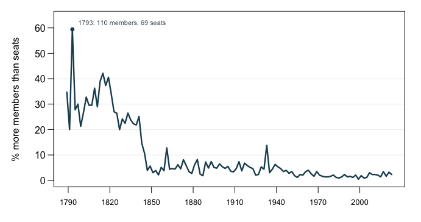

Hover for each Congress's members, seats and excess.

**Figure 1. Members in excess of seats, as a share of that Congress’s seats, for every Congress since 1789.** A line fits this question because it is one quantity measured 118 times at even intervals, and the finding is the shape of the series. The churn reaches 59.4% of the chamber in 1793, and has fallen to 2.3% in the Congress elected in 2022.

Every one of those 2,344 extra people arrived **mid-Congress**, and that is not an approximation — it is the same number counted a second way, and the table at the end of this chapter records the check. They were seated after a special election, or after a contested result was resolved, or to fill a vacancy. **No general election for that Congress put them there.** 744 of the vacancies they filled were created by a death in office.

One recent Congress shows how the count works. The 117th Congress, elected in November 2020, had 435 seats and seated 449 people — 14 more than there were chairs, 6 of them filling a seat emptied by a death. Texas’s 6th district is one of those. The November 2020 return names Ron Wright as the winner. Wright died in February 2021, and a special election that July seated Jake Ellzey in the same chair.[^1] The roster for that Congress therefore carries two names against one seat, and Ellzey appears in no general-election return for it, because there was no general election for him to win. Count 14 such arrivals and a 435-seat chamber has 449 members.

This is the practical consequence: a file of general-election returns, however complete, cannot account for 6.2% of the people who have held a seat in the House. Ask a returns file who represented a district in 1815 and it will name the person who won the election, which in the 14th (1815) Congress was frequently not the person doing the job.

Why the early chamber churned so much is a question the roster can pose and cannot answer. It records the arrivals, the deaths, and the dates; it does not record why so many members resigned partway through a term. The record holds acts, and the reasons have to come from somewhere else.

## Most departures are not decided by voters

The gap runs the other way too. Ask why a member stopped serving, and the election explains less than you would expect.

| Outcome | Members | Decided by a voter |
| --- | --- | --- |
| re-elected | 3,653 | — |
| did not seek re-election | 387 | no |
| defeated in the general election | 225 | yes |
| ran for the Senate | 102 | no |
| denied renomination | 58 | yes |
| died in office | 18 | no |

Over the 10 most recent Congresses, 790 members stopped serving. A voter decided **283** of those departures — losing a general election, or being denied renomination in a **primary**, the party’s own election that picks its candidate. The other **507**, or **64.2%**, were not decided by any voter at all: the member retired, ran for the Senate, or died.

**Roughly two thirds of the turnover in the House is not an electoral event.** That is a fact about the institution which no return can report, and it is exactly the fact that `retirements` and `careers` exist to study.

This is why every brief in this cluster reads the roster first and joins the returns to it. The roster supplies the people and the durations; the returns supply the verdicts, where a verdict exists; and neither record answers the other’s question. `careers` strings one person’s terms into a career. Of 13,320 careers in the file, **1,175 are not one continuous stretch**, 8.8% of them — and a returns file has no way to know they belong to the same person. `primary-defeats` matches 3,936 incumbent-primary rows to the roster by name and district.

A roster is also the only way to answer who was actually in the room. Whether a bill passed depends on who held the seat that week, not on who won the election two years earlier. That is why the roll-call chapters in the next part begin from a membership file rather than from returns.

## What this data cannot tell you

**It cannot tell you why anyone left.** The outcome column is a classification built from what the file records — appeared on a ballot, did not, died. A retirement that was really a pre-emption of certain defeat is recorded as a retirement, because that is all the roster knows.

**It cannot reconcile the two kinds of file for you.** Matching a roster to a returns file is its own problem, and `primary-defeats` is where it is done, reporting the failures rather than dropping them.

**It cannot be extended backwards indefinitely.** The membership series runs across 118 Congresses; the departure classification depends on candidate filings and runs over 10. The two-thirds finding is a modern one, and this chapter does not claim it held in 1815.

**And it cannot tell you who the voters wanted.** That is the returns file’s question, and the point of putting the two records beside each other is that neither one answers both.

## What you should have learned

- A return records a contest and a roster records a membership. Both are official, both are complete, and they answer different questions.
- 40,432 people have served in 38,088 House seat-terms — 2,344 more people than seats, every one of them seated by something other than that Congress’s general election.
- The churn is historical: mid-Congress arrivals reach 59.4% of seats in 1793 and stand at 2.3% in the most recent Congress in the file.
- Over the 10 most recent Congresses, 64.2% of departures from the House were decided by no voter at all.
- A roster is silent about votes the way a return is silent about voters: the party-divisions series carries 0 vote totals, because it counts seats.

## Where this data appears in this book

This chapter leads cluster III.2. The Clerk of the House publishes the official election statistics Congress keeps about itself, and how to read that typeset record is covered inside the uncontested-races brief. Eight briefs then run on rosters, mostly joined to returns:

- `house-competition` — uncontested House races since 1946, and how one name on a ballot became ordinary.
- `midterm-loss` — the midterm penalty since 1858, counted from party divisions.
- `retirements` — two centuries of members leaving the House, and why the roster cannot say why.
- `primary-defeats` — incumbents denied renomination, matched from roster to returns.
- `primary-positions` — fourteen issues, 1,662 primary candidates, and a code that means nobody mentioned it.
- `nomination-anchors` — fifty-five nominations from a study whose dataset was never released.
- `nomination-rules` — the vote share that picks a nominee, found without reading a statute.
- `careers` — how long a congressional career lasts, and the arithmetic that counts unfinished ones.

## Sources

Nothing in this chapter was downloaded. Every figure is read from the derived tables four other chapters already built:

- `retirements` — `departures.csv`, `exits.csv`. Members and seats by Congress, and why each member stopped serving.
- `careers` — `careers.csv`. One row per career, with the gaps.
- `midterm-loss` — `house_midterms.csv`. Party divisions by election.
- `primary-defeats` — `incumbents.csv`. Incumbents facing a primary, matched to the roster.

Three files sit underneath them, and each is published free of charge: Voteview’s membership file (Jeffrey B. Lewis and colleagues, downloadable at https://voteview.com/data), the Office of the Historian’s Party Divisions tables (https://history.house.gov/Institution/Party-Divisions/Party-Divisions/) and the Federal Election Commission’s *Federal Elections* compendium (https://www.fec.gov/introduction-campaign-finance/election-results-and-voting-information/). The *Biographical Directory of the United States Congress* is the chambers’ own roster (https://bioguide.congress.gov/). The four chapters above document what each file cost to get and what it left out; this chapter’s subject is what the records have in common.

Every figure above is recomputed from those tables, and checked against the values asserted in `checks.csv`. The table is printed here verbatim.

**The data itself**

Every figure above is drawn from these tables. They are plain CSV, they open in a spreadsheet, and they are yours to take further.

`careers.csv`, `excess.csv`, `exits.csv`, `rosters.csv`

One more file is not data about the subject – it is how this chapter checked its own work: `checks.csv`, the arithmetic verified before anything was drawn.

**Your turn**

None of these is answered above, and every one can be answered from the tables you just opened.

- `excess.csv` shows more members than seats in almost every Congress, with `mid_congress` and `died` beside `excess`. Follow `excess` across the series. Is the churn falling steadily, or in steps?
- `exits.csv` flags whether each departure was `voter_decided`. Work out what share of exits in the `members` column the voters actually chose. Does that match how congressional turnover is usually described?
- `rosters.csv` says in `answers` what each record can settle and in `silent_about` what it cannot. Pick a question you would want answered and decide whether any roster can settle it.
- A roster and a return disagree about how many people held a seat. Using the `mid_congress` and `died` columns of `excess.csv`, work out where the extra people come from, and how many arrived by something other than a death.

| Check | Value |
| --- | --- |
| Rosters described | 3 |
| Chapters read, none of them downloaded | 4 |
| Congresses in the membership series | 118 |
| People who have served in the House | 40,432 |
| Seats that have existed to serve in | 38,088 |
| Excess of people over seats | 2,344 |
| Excess as a share of seats, % | 6.2 |
| Mid-Congress arrivals (identical to the excess, by construction) | 2,344 |
| Seats emptied by a death in office | 744 |
| Worst single Congress: members | 199 |
| Worst single Congress: seats | 140 |
| Worst single Congress: which, and when | 14th (1815) |
| Congresses in the modern exit file | 10 |
| Departures in that file | 790 |
| Departures a voter decided | 283 |
| Departures no voter decided | 507 |
| Share no voter decided, % | 64.2 |
| Careers in the career file | 13,320 |
| Careers that are not one continuous interval | 1,175 |
| Columns in the party-divisions series carrying a vote total | 0 |
| Incumbent-primary rows available for matching | 3,936 |

[^1]: The House Historian’s entries for both members: https://history.house.gov/People/Listing/W/WRIGHT,-Ron-(W000827)/ and https://history.house.gov/People/Listing/E/ELLZEY,-Jake-(E000071)/.